# GGPlot

Data Science at Sac State

September 22, 2017

# GGPlot2

“ggplot2 is a data visualization package for the statistical programming language R. Created by Hadley Wickham in 2005, ggplot2 is an implementation of Leland Wilkinson’s Grammar of Graphics—a general scheme for data visualization which breaks up graphs into semantic components such as scales and layers.” - https://en.wikipedia.org/wiki/Ggplot2

## Cheat Sheet

When starting to learn ggplot, remembering abbreviations can be tricky. Here’s a cheat sheet with various functions and graphing types:

https://www.rstudio.com/wp-content/uploads/2015/03/ggplot2-cheatsheet.pdf.

## Setup

(Run install.packages(‘ggplot2’) to install)

```r
library(ggplot2)
```

## Basics

To make a graph, call ‘ggplot()’ and then append what you’d like to display (like layering components together). The simplest graph of this form follows, using a range of values along the X axis and Y axis.

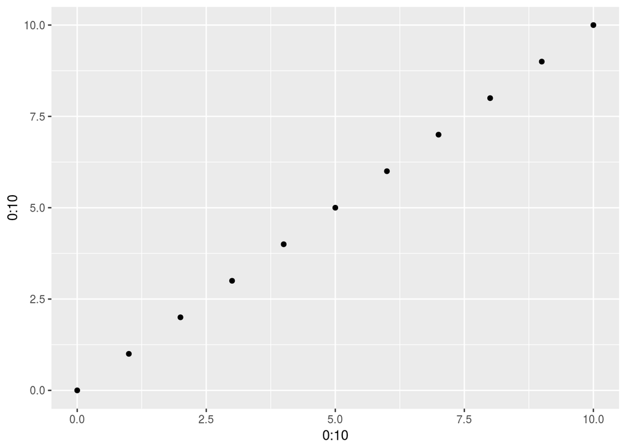

```r
ggplot() + geom_point(aes(x = 0:10, y = 0:10))
```

We don’t have to provide a value expression in the aes, we can also provide column names - so long as we provide the “data” argument to ggplot with the data frame containing our columns.

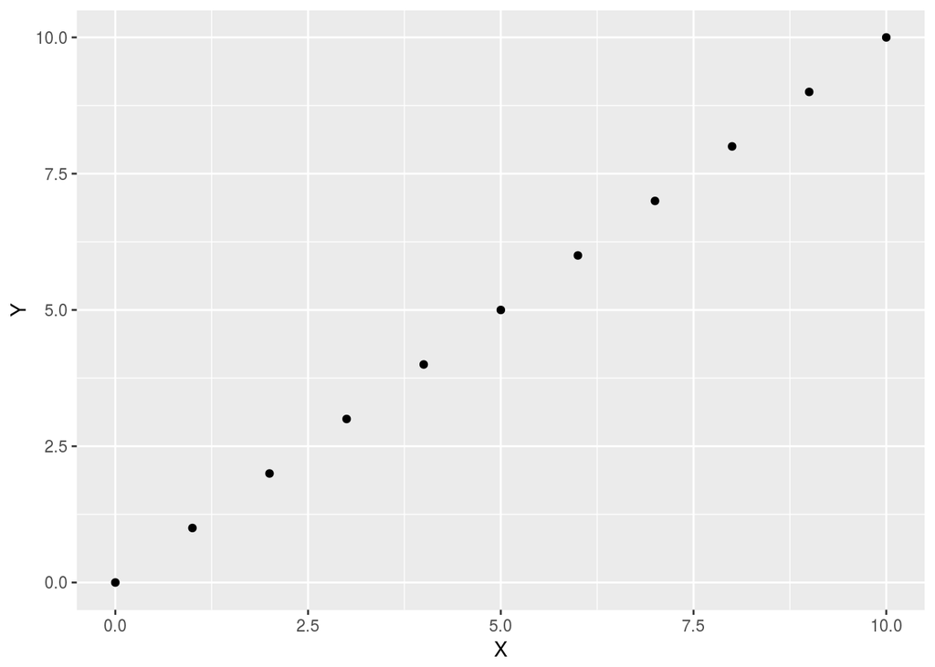

```r
# Mock data in a dataframe (same "ranges" as before)
df = data.frame(X = 0:10, Y = 0:10)

# ggplot will resolve the column names using the data frame
ggplot(data = df) +
  geom_point(aes(x = X, y = Y))
```